# Final Project

Sha Li

December 13, 2016

### Problem Statement

The income difference between male and female has long been a heated topic for social discussion.The target of this report is to study whether gender has a significant impact on income? Moreover, does any other factor influence the income gap between male and female? This report will mainly focus on the impact of educational and residencial factors. The dataset used is the NLSY79 (National Longitudinal Survey of Youth, 1979 cohort) data set. The NLSY79 data set contains survey responses on thousands of individuals who have been surveyed every one or two years starting in 1979.

### 1 Data Summary

#### 1.1 Transforming Data

Let’s begin by loading the packages, inputing the data, and chooseing the variables.In this report, the following variables will be used for analysis: (1) Dependent Variable: T3977400 Income (2) Independent Variable: a. R0214800 Gender b. Educational factors: R0023500 Highest grade expect to complete(1979); R0171800 Expect in school or not in 5yrs; R34015.01 Highest grade completed(May.1.1990);T4113000 HIghest grade completed(May.1.2012) c. Residential factors: R0000700 Born in US or not; R0001010 South-nonsouth place of birth in US; R0001610 South-nonsouth place of birth in US at age 14; R0001800 Area of residence at age 14 urban/rural;T4112700 Region of Current Residence; T4114600 Current Residence urban/rural

To keep the consistence of the analysis and to achieve more stable results, I dropped all the zero and negative values in income, and set all the negative values in other variables as unknown.

```
##      Income          Gender                   COB          POB_South
##  Min.   :    45   Female:2615   In Other Country: 350   NonSouth:3013
##  1st Qu.: 23000   Male  :2660   In the US       :4924   South   :1838
##  Median : 40000                 Unknown         :   1   Unknown : 424
##  Mean   : 54774
##  3rd Qu.: 65000
##  Max.   :343830
##
##    RES_South14                 RES_Urban14            High_Grade79
##  NonSouth:3274   In country- not farm: 846   12th Grade     :1946
##  South   :1835   In town or city     :4157   4th yr College :1461
##  Unknown : 166   On farm or ranch    : 256   2nd yr College : 700
##                  Unknown             :  16   6th+ yr College: 323
##                                              5th yr College : 281
##                                              1st yr College : 157
##                                              (Other)        : 407
##          Edu_Exp5yr           High_Grade90            Region
##  In school    :2137   12th Grade    :2195   North Central:1258
##  Not in school:2983   4th yr College: 699   Northeast    : 798
##  Unknown      : 155   2nd yr College: 492   South        :2157
##                       1st yr College: 485   Unknown      :  33
##                       3rd yr College: 274   West         :1029
##                       11th Grade    : 196
##                       (Other)       : 934
##          High_Grade12      Urban
##  12th Grade    :2176   Rural  :1029
##  4th yr College: 728   Unknown: 129
##  2nd yr College: 564   Urban  :4117
##  1st yr College: 484
##  3rd yr College: 299
##  6th yr College: 257
##  (Other)       : 767
```

We can see from the summary that after drop the zero and negative values in income, we have very few respondents born in other country, so we will drop the COB variable.

```
##      Income          Gender        POB_South      RES_South14
##  Min.   :    45   Female:2615   NonSouth:3013   NonSouth:3274
##  1st Qu.: 23000   Male  :2660   South   :1838   South   :1835
##  Median : 40000                 Unknown : 424   Unknown : 166
##  Mean   : 54774
##  3rd Qu.: 65000
##  Max.   :343830
##
##                RES_Urban14            High_Grade79          Edu_Exp5yr
##  In country- not farm: 846   12th Grade     :1946   In school    :2137
##  In town or city     :4157   4th yr College :1461   Not in school:2983
##  On farm or ranch    : 256   2nd yr College : 700   Unknown      : 155
##  Unknown             :  16   6th+ yr College: 323
##                              5th yr College : 281
##                              1st yr College : 157
##                              (Other)        : 407
##          High_Grade90            Region             High_Grade12
##  12th Grade    :2195   North Central:1258   12th Grade    :2176
##  4th yr College: 699   Northeast    : 798   4th yr College: 728
##  2nd yr College: 492   South        :2157   2nd yr College: 564
##  1st yr College: 485   Unknown      :  33   1st yr College: 484
##  3rd yr College: 274   West         :1029   3rd yr College: 299
##  11th Grade    : 196                        6th yr College: 257
##  (Other)       : 934                        (Other)       : 767
##      Urban
##  Rural  :1029
##  Unknown: 129
##  Urban  :4117
##
##
##
##
```

#### 1.2 Gender and Income

After cleaning the data, we can take a look at the basic gender and income statistics of the rest survey respondents.

##### 1.2.1 Gender

Among the 5275 survey respondents, there are 2660men, and 2615 women. So 50.43% of all the respondents are males, and 49.57% are females.

##### 1.2.2 Income

Income distribution is demonstrated in the following boxplot.

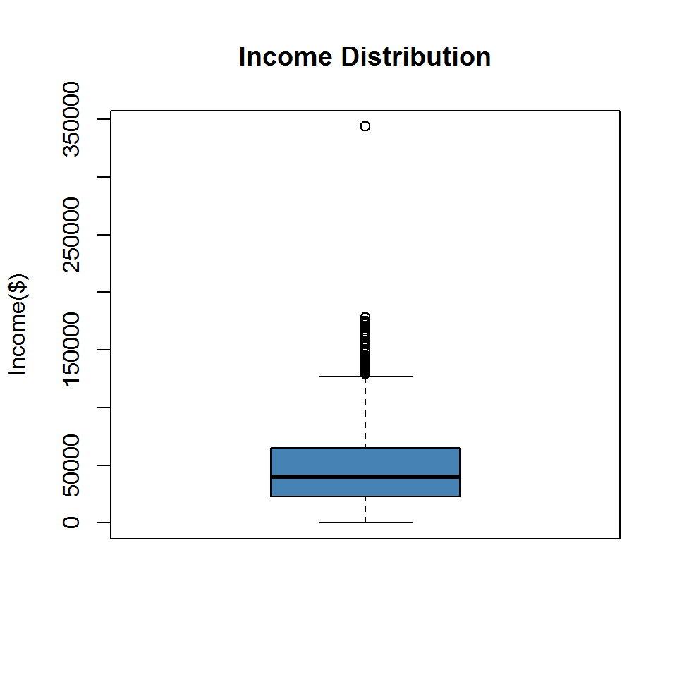

From the Income Distribution Boxplot, we can see that there is an obious outlier skewed the plot. We know it’s the 2% earners whose incomes have been topcoded. To overview a better income distribution among the majority of people, I drop the topcoded incomes.

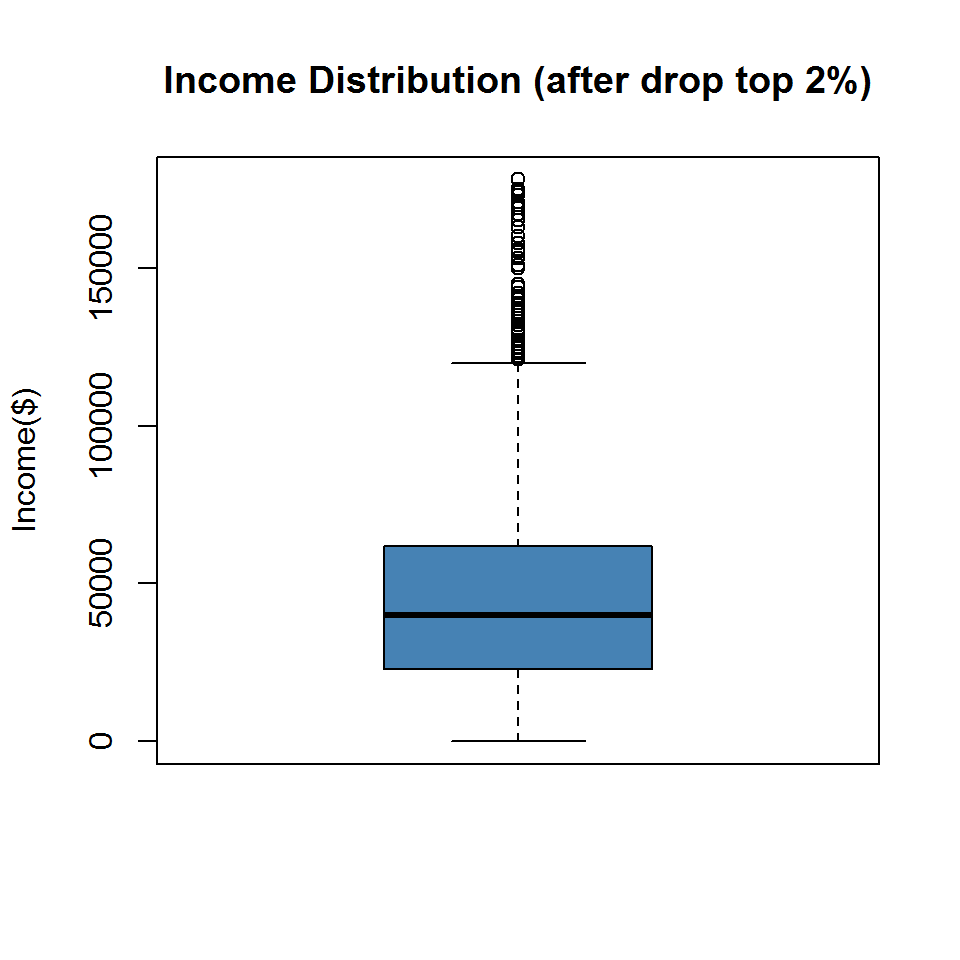

From the new boxplots incurred after drop the top 2% earners, we can see that 3/4 of the respondents own an income from 0 to slightly over $50,000. There are still some outliers have higher incomes over $150,000, the plot is less skewed than prior dropping the top 2%.

##### 1.2.3 Income Distribution by Gender

Next, let’s take a look at the breakdown of income by gender.

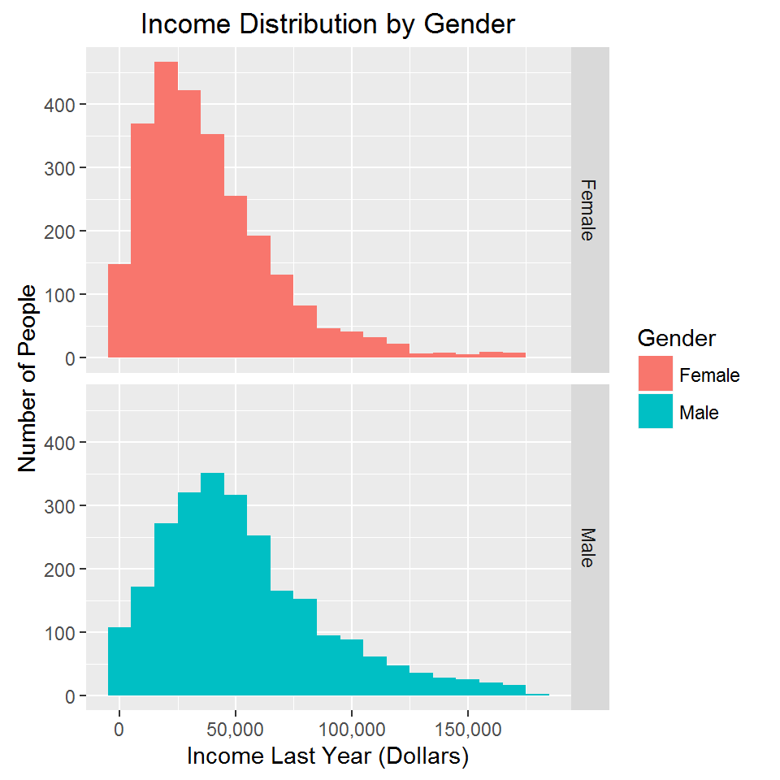

| Gender | Mean.income | Median.income | Sd.income | Min.income | Max.income |
| --- | --- | --- | --- | --- | --- |
| Female | 39460.17 | 33200 | 29062.05 | 45 | 175000 |
| Male | 54190.78 | 48000 | 35625.24 | 72 | 178000 |

The plot and table above have demostrated the income distributions of males and females respectively. The average income for females is $39460.17, with a standard deviation of $29062.05. The average income for males is $54190.78 with a standard deviation of $35625.24.

#### 1.3 Education

After developed an understanding of the key variables gender and income, we now move on to educational related variables. There are four variables in the dataset jointly picture the education background and expectation of the survey respondents.

##### 1.3.1 Average Income across education level in different years

Let’s start by taking a look at the respondents’ expected degree in 1979, the degree completed in 1990, and 2012. The table is too long, so we just show the 10 highest average income.

|  | High_Grade79 | High_Grade90 | High_Grade12 | Income |
| --- | --- | --- | --- | --- |
| 412 | 2nd yr College | 7th yr College | 8th+ yr College | 170000 |
| 420 | 5th yr College | Unknown | 8th+ yr College | 170000 |
| 269 | 1st yr College | 2nd yr College | 5th yr College | 140000 |
| 305 | 5th yr College | 1st yr College | 6th yr College | 133000 |
| 351 | 2nd yr College | 2nd yr College | 7th yr College | 125000 |
| 414 | 5th yr College | 7th yr College | 8th+ yr College | 123800 |
| 303 | 2nd yr College | 1st yr College | 6th yr College | 120000 |
| 372 | 5th yr College | 8th+ yr College | 7th yr College | 120000 |
| 413 | 4th yr College | 7th yr College | 8th+ yr College | 116625 |
| 257 | 5th yr College | Unknown | 4th yr College | 110000 |

##### 1.3.2 Grade completion vs Education expectation

The next thing I am very interested to know when I first saw the data is that whether the respondents’ expectations for their education are accurate. Same as the table above, list the respondents with 10 highest average income. We can see that no matter the respondents expect themselves in or not in school in 5 years, their completed grades in 1990 are higher than their expected complete grade in 1979. This might becaue the average education years in the society has increased during the years. (Notice that the options in the questions also have changed, with a highest grade of 6+ yrs college in 1979 survey raised to 8th+ yr in 1990). The 6 respondens on 6th row who have expected themselves to be 3rd yr college, but they ends up to be complete with 10th grade by 1990. I am not quite sure how to explain this.

|  | High_Grade79 | Edu_Exp5yr | High_Grade90 | Income |
| --- | --- | --- | --- | --- |
| 207 | 2nd yr College | In school | 7th yr College | 170000.0 |
| 229 | 4th yr College | In school | 8th+ yr College | 123000.0 |
| 233 | 5th yr College | Not in school | 8th+ yr College | 122250.0 |
| 213 | 5th yr College | Not in school | 7th yr College | 116333.3 |
| 231 | 6th+ yr College | In school | 8th+ yr College | 113684.4 |
| 6 | 3rd yr College | In school | 10th Grade | 107000.0 |
| 214 | 6th+ yr College | Not in school | 7th yr College | 101600.0 |
| 160 | 4th yr College | Unknown | 4th yr College | 101153.3 |
| 209 | 5th yr College | In school | 7th yr College | 100900.0 |
| 190 | 2nd yr College | Not in school | 6th yr College | 100500.0 |

##### 1.3.3 Income by Highest Degree Completed

Glance at the tables above, we can see that income is most strongly related to the highest degree achieved in 2012. So we make some further analysis on the correlation between respondents’ income and their highest grade completed in 2012 to see whether our glance is right.

|  | High_Grade12 | Income |
| --- | --- | --- |
| 17 | 8th+ yr College | 82310.59 |
| 15 | 7th yr College | 72478.86 |
| 13 | 6th yr College | 68640.32 |
| 9 | 4th yr College | 65126.32 |
| 11 | 5th yr College | 62443.83 |
| 5 | 2nd yr College | 47252.78 |
| 7 | 3rd yr College | 45887.98 |
| 4 | 1st yr College | 43616.88 |
| 3 | 12th Grade | 38320.61 |
| 10 | 5th Grade | 28000.00 |
| 16 | 8th Grade | 27254.55 |
| 2 | 11th Grade | 26406.01 |
| 18 | 9th Grade | 25551.81 |
| 8 | 4th Grade | 24675.00 |
| 1 | 10th Grade | 24279.34 |
| 12 | 6th Grade | 23038.57 |
| 6 | 3rd Grade | 22133.33 |
| 14 | 7th Grade | 20364.29 |

[figure not shown]

```
##                Df    Sum Sq   Mean Sq F value Pr(>F)
## High_Grade12   17 9.010e+11 5.300e+10   56.67 <2e-16 ***
## Residuals    5114 4.783e+12 9.354e+08
## ---
## Signif. codes:  0 '***' 0.001 '**' 0.01 '*' 0.05 '.' 0.1 ' ' 1
```

We can see the P value is <0.001, which means the variable highest grade completed in 2012 is statistically significant.

##### 1.3.4 Gender Income Gap across Education levels

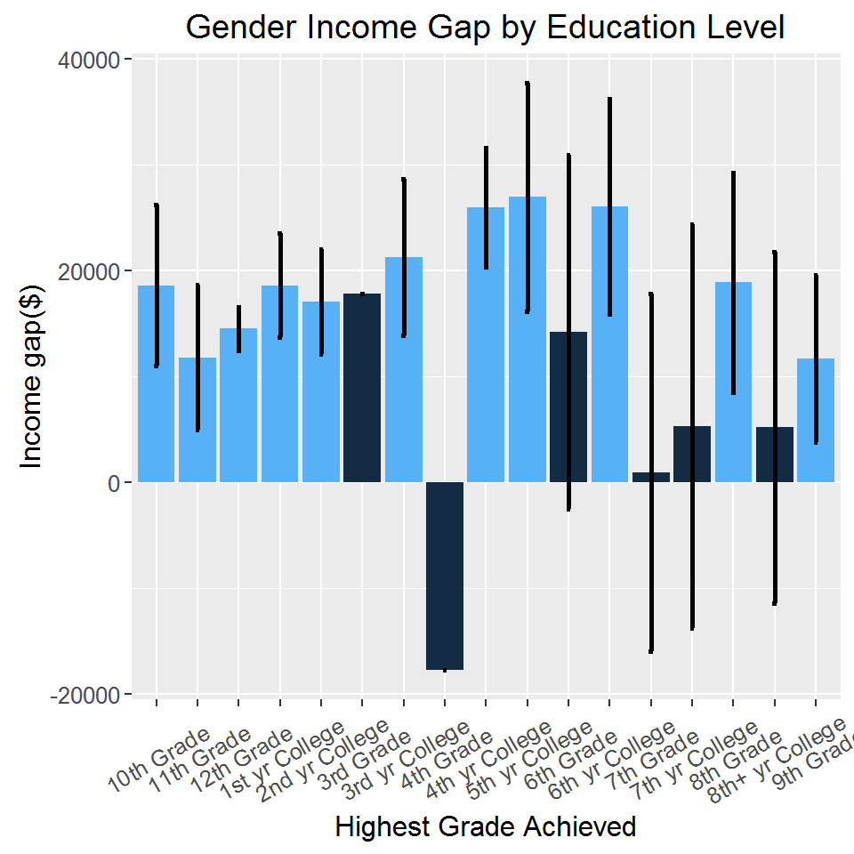

#### 1.4 Residence

Apart from education, residence is also an important factor influencing the income.

##### 1.4.1 Place of Birth

|  | Gender | POB_South | Income |
| --- | --- | --- | --- |
| 2 | Male | NonSouth | 76694.43 |
| 6 | Male | Unknown | 63904.75 |
| 4 | Male | South | 55703.99 |
| 1 | Female | NonSouth | 42513.59 |
| 5 | Female | Unknown | 40562.09 |
| 3 | Female | South | 38280.54 |

```
##               Df    Sum Sq   Mean Sq F value   Pr(>F)
## POB_South      2 7.170e+10 3.585e+10   32.75 7.36e-15 ***
## Residuals   5127 5.612e+12 1.095e+09
## ---
## Signif. codes:  0 '***' 0.001 '**' 0.01 '*' 0.05 '.' 0.1 ' ' 1
```

We can see that regardless of place of birth, males’ income are higher than females. Meanwhile, in the same gender, the respondents who born in nonsouth area have higher income than those who born in South.

##### 1.4.2 Urban vs Rural

|  | Gender | Urban | Income |
| --- | --- | --- | --- |
| 6 | Male | Urban | 70861.51 |
| 4 | Male | Unknown | 60400.42 |
| 2 | Male | Rural | 59877.85 |
| 5 | Female | Urban | 41942.99 |
| 1 | Female | Rural | 37153.34 |
| 3 | Female | Unknown | 35533.19 |

We can see from the table that males’ income are higher than females’ in general. And within the gender group, those respondents who live in urban area tend to have higher income than those in rural area.

##### 1.4.3 Current Residence

|  | Gender | Region | Income |
| --- | --- | --- | --- |
| 4 | Male | Northeast | 80738.30 |
| 2 | Male | North Central | 69990.34 |
| 10 | Male | West | 67315.74 |
| 6 | Male | South | 63699.51 |
| 8 | Male | Unknown | 57096.67 |
| 3 | Female | Northeast | 44708.74 |
| 9 | Female | West | 43724.74 |
| 5 | Female | South | 39624.64 |
| 7 | Female | Unknown | 38949.17 |
| 1 | Female | North Central | 38380.28 |

For males, the income sequence from high to low is northeast > north centeral > west > south. For females, the income sequence from high to low is northeast > west > south > north central.

### 2 Methodology

#### 2.1 Missing Values

My main focus of this study is to see the effect of education level and area of residence on respondents’ income. The reasons why the value is missing in a certain variable might not be relevant to this study. So I didn’t take the different kinds of skip into consideration. To run a better regression and achieve more constant and stable result, I dropped zero and negative values of income at the very beginning, and changed negative values in other variables as “unknown”.

#### 2.2 Topcoded Values

I dropped topcoded values at the beginning right after plotting the income distribution. Now I will run two linear regression model to show the difference before and after drop the topcoded values.

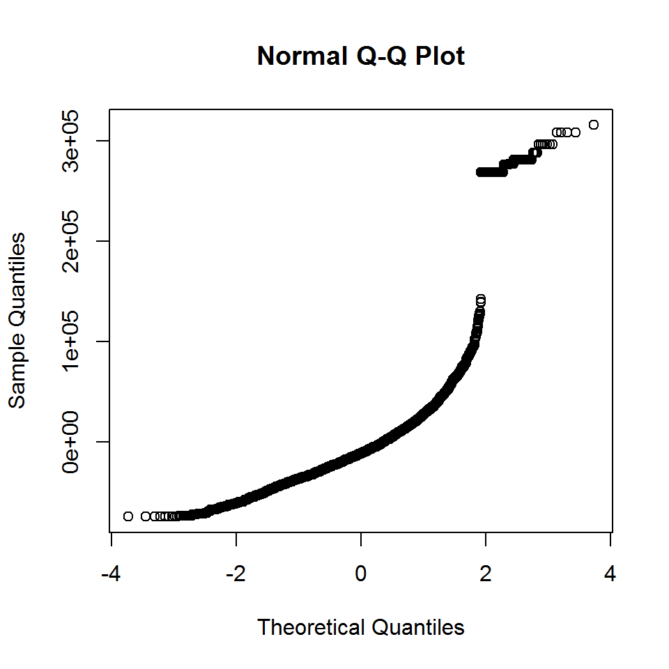

After drop the topcoded values.

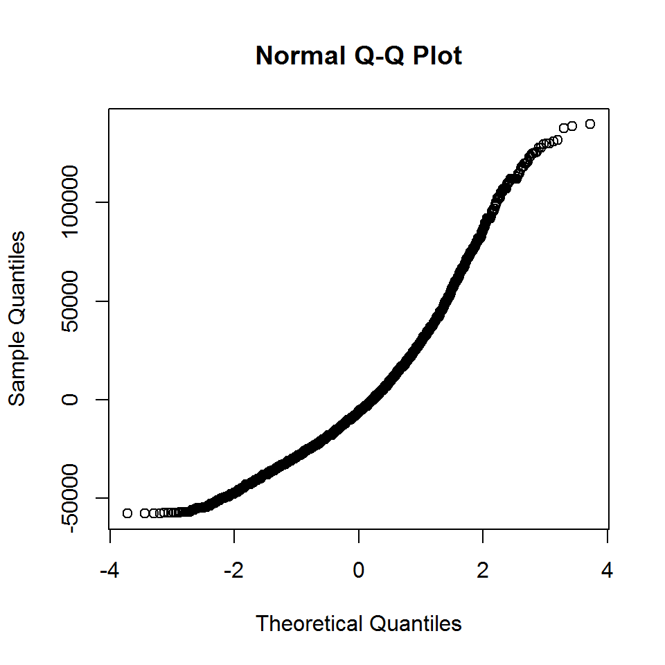

Comparing the two normal Q-Q plots, we can see that model has been improved after drop the top 2% highest income earners.

#### 2.3 Consideration

The variable Highest Grade achieved in 2012 has too many levels which will be too complicated to be an interactive factor when running a regression. So I categorize the grades into primary school, middle school and college.

### 3 Findings

#### 3.1 Regression Output

The final regression model runs with the following formula:

##### Income ~ Gender + POB_South + Region + Urban + Gender*POB_South + Gender*grade

```
##
## Call:
## lm(formula = Income ~ Gender + Region + Urban + Gender * POB_South +
##     Gender * grade, data = nlsy_new)
##
## Residuals:
##    Min     1Q Median     3Q    Max
## -73354 -20087  -4823  14302 129942
##
## Coefficients:
##                             Estimate Std. Error t value Pr(>|t|)
## (Intercept)                  45861.9     1431.1  32.046  < 2e-16 ***
## GenderMale                   22251.0     1378.6  16.140  < 2e-16 ***
## RegionNortheast               4807.3     1411.2   3.407 0.000663 ***
## RegionSouth                   3800.3     1375.1   2.764 0.005738 **
## RegionUnknown                 -613.3     6319.1  -0.097 0.922689
## RegionWest                    2041.6     1320.2   1.546 0.122059
## UrbanUnknown                  1270.4     3270.3   0.388 0.697685
## UrbanUrban                     833.7     1084.2   0.769 0.441948
## POB_SouthSouth               -5437.7     1526.7  -3.562 0.000372 ***
## POB_SouthUnknown               125.8     2413.1   0.052 0.958419
## gradePrimary                -31271.4     9401.3  -3.326 0.000886 ***
## gradeSecondary              -18098.0     1207.5 -14.989  < 2e-16 ***
## GenderMale:POB_SouthSouth    -5171.0     1824.2  -2.835 0.004605 **
## GenderMale:POB_SouthUnknown  -2663.4     3279.5  -0.812 0.416739
## GenderMale:gradePrimary      -8982.3    12792.4  -0.702 0.482609
## GenderMale:gradeSecondary    -6145.2     1717.9  -3.577 0.000350 ***
## ---
## Signif. codes:  0 '***' 0.001 '**' 0.01 '*' 0.05 '.' 0.1 ' ' 1
##
## Residual standard error: 30360 on 5114 degrees of freedom
## Multiple R-squared:  0.1707, Adjusted R-squared:  0.1682
## F-statistic: 70.16 on 15 and 5114 DF,  p-value: < 2.2e-16
```

#### 3.2 Coefficients Interpretation

##### Gender

Our regression outcome shows that gender is a statistically significant predictor of income since its p-value is <0.001. The coefficient is 22251, which means holding other factors constant, males earn $22251 more than females.

##### Current Residence

Current residence don’t have a very strong impact on income.

With all other factors being constant:

Respondents live in Northeast earn $4807.3 more than respondents live in North Central.

Respondents live in South earn $3800.3 more than respondents live in North Central.

Respondents live in West earn $2041.6 more than respondents live in North Central.

Respondents live in urban earn $833.7 more than respondents live in rural.

##### Plce of Birth

Whether a respondent is born in South US has significant impact on the income.

With all other factors being constant:

Respondents born in South earn $5437.7 less than respondents born in Nonsouth.

##### Highest Grade Achieved

Grade is a statistically significant predictor of income.

With all other factors being constant:

Respondents with a highest degree in primary school earn $31271.4 less than respondents with a highest degree in college.

Respondents with a highest degress in secondary school earn $18098 less than respondents with a highest degree in college.

#### 3.3 Diagnostic Plots

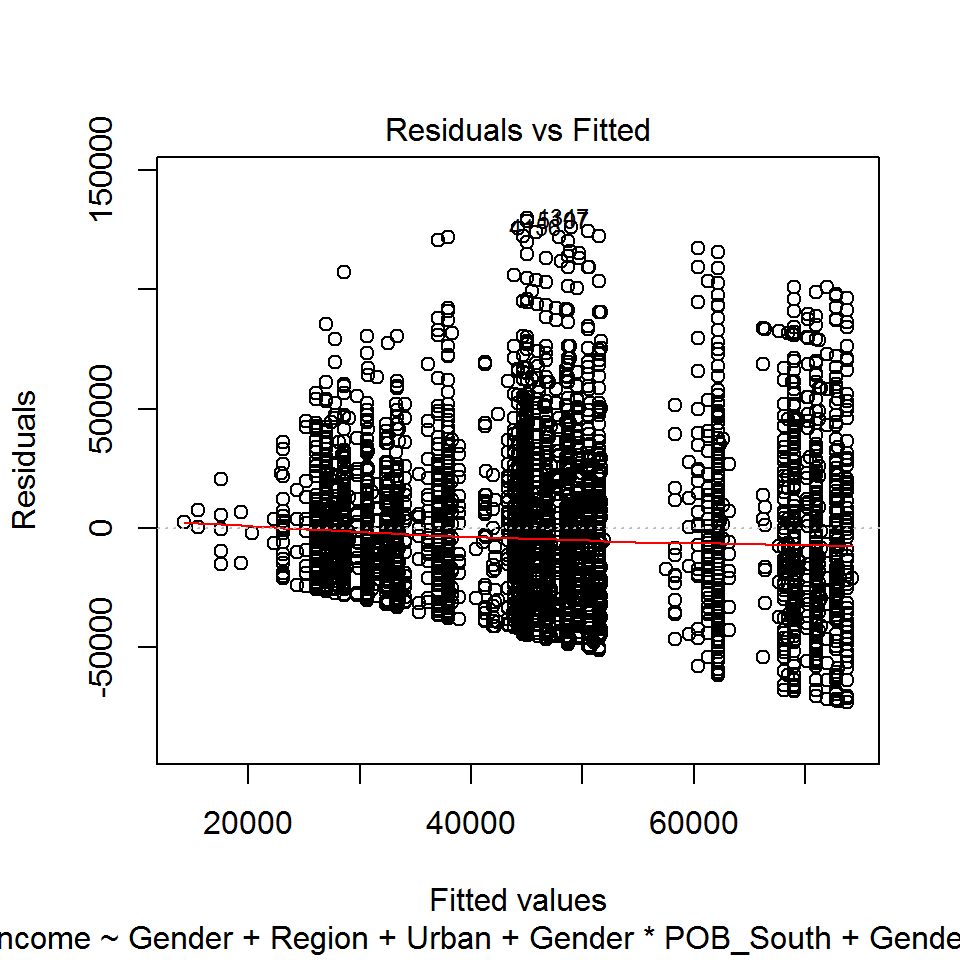

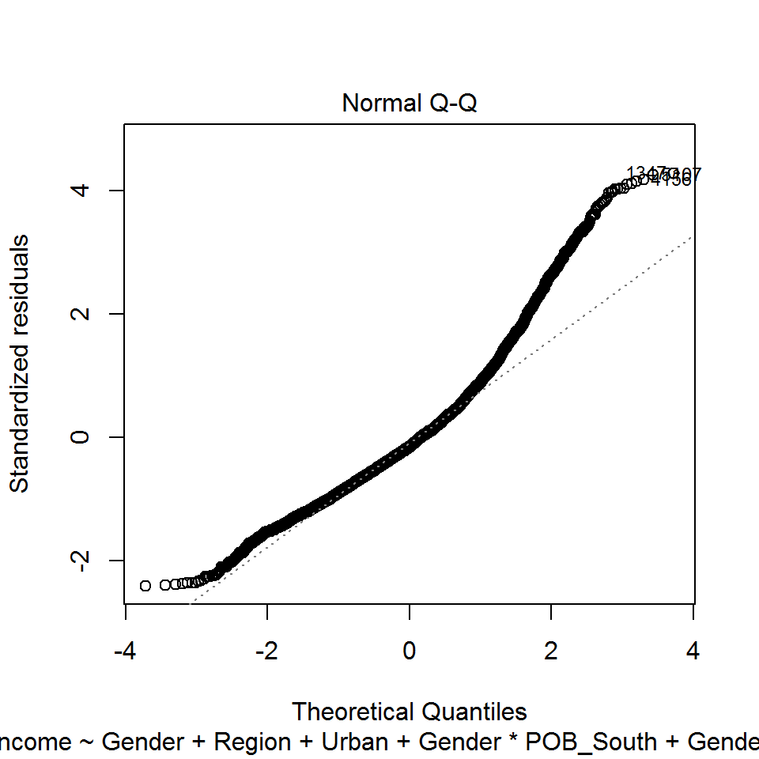

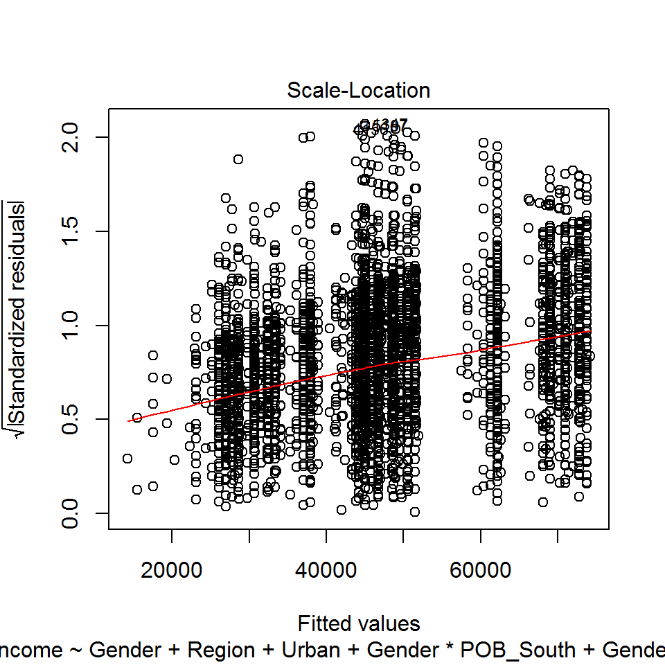

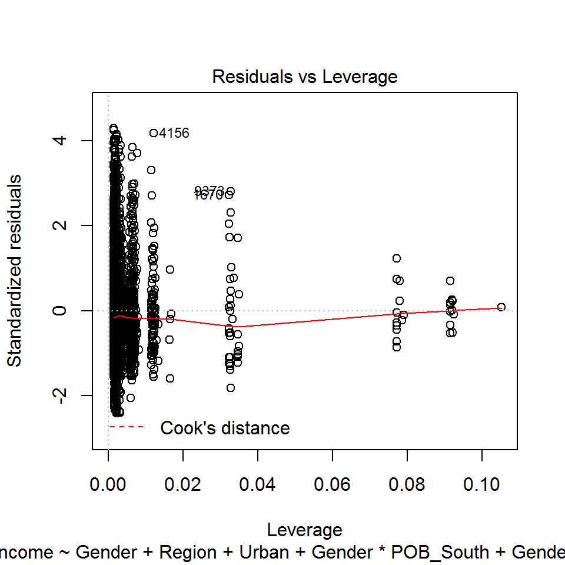

Residual vs Fitted: In this plot, the red line is not perfectly flat, which means the variance is not perfectly constant.

Normal Q-Q: In this QQ Plot, the residuals depart significantly from the diagonal line in upper tail of the distribution. This indicates that the residuals are not normally distributed. we see that the tails are observed to be ‘heavier’ (have larger values) than what we would expect under the standard modeling assumptions. This is indicated by the points forming a “steeper” line than the diagonal.

Residuals vs Leverage: All cases are well inside of the Cook’s distance lines.

#### 4 Discussion

In this report, we have discussed whether there is a inome gap between males and females, and what other factors have impact on the gender income gap. We tried variables related to education and residence, and narrowed down the predictors included in the final regression model to the following:Gender, place of birth south or nonsouth in the US, currently live in urban or rurual, currently live in which part of the US, and the highest grade completed in 2012.

From the analysis, we can draw a conlcusion that there certainly is a income gap between males and females. In most cases, respondents have higher degrees achieved tend to have higher incomes. People born in nonsouth in the US, and currently live in urban and northeast in the US also tend to have higher income.

From the diagnostic plots, we can see some problems in the final model.The slightly nonconstant variance, and nonnormal distribution might reduce the confidence of the model. For people who have higher income, the predicition might be slightly lower than their actual income. The exclusion of 2% topcoded data is another limitation of the model.

I wasn’t able to find a way to check the longitudinal effect of education completed and expectation. I think it might be interesting to see whether the respondents educational expectancy allign with the grade they actually completed.

All in all, there isn’t any obvious counter intuitive result from the study.So I think my analysis makes sense in some extent.